# Coursera Project - PM2.5 Emissions Data

Tom Polak

November 21, 2017

# Emissions Data Plot Analysis

This analysis is generated from the National Emissions Inventory (NEI) dataset between 1999-2008. Specifically the dataset has all PM2.5 pollutants from a variety of different sources throughout the United States.

In order to better understand the trends over time of the amount of PM2.5 pollutant, 6 questions were posed. The plots below are an attempt to measure/identify the relationship posed.

## Question 1

Have total emissions from PM2.5 decreased in the United States from 1999 to 2008? Using the **base** plotting system, make a plot showing the *total* PM2.5 emission from all sources for each of the years 1999, 2002, 2005, and 2008.

```r
# Question 1
EmissionsSummary_Total <- PMData %>%
  group_by(year) %>%
  summarise(TotalEmissions = sum(Emissions)/1000,
            AvgEmissions = mean(Emissions))
```

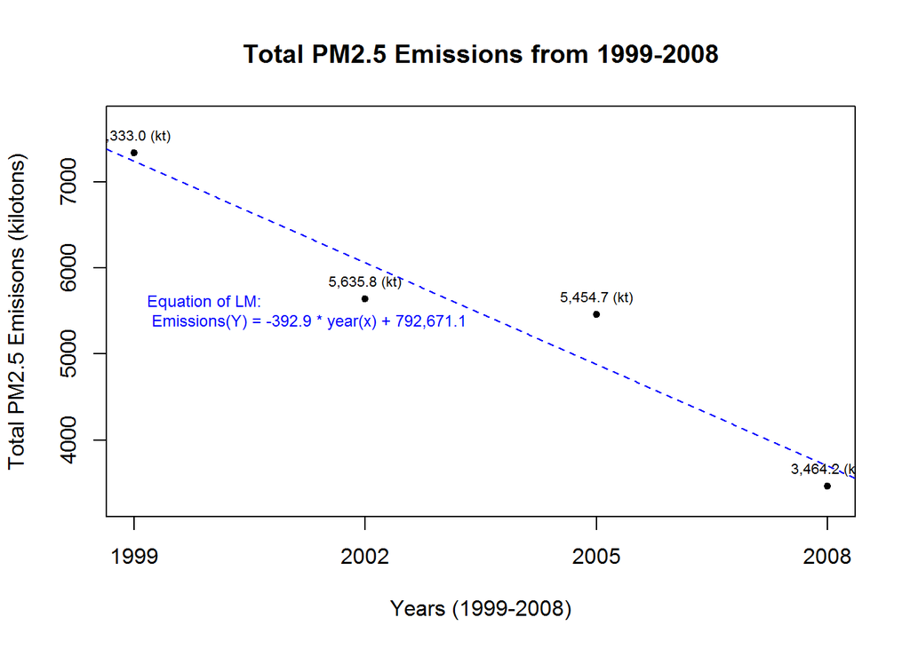

```r
modelTotal <- lm(TotalEmissions ~ year,EmissionsSummary_Total)
modelTotalEquation <- paste('Equation of LM:\n Emissions(Y) =', format(coef(modelTotal)[[2]],nsmall =1, digits = 1,big.mark = ","), '* year(x)', '+', format(coef(modelTotal)[[1]],nsmall =1, digits = 2, big.mark = ","))

par(mar=c(5,4,4,2)+0.1)
with(EmissionsSummary_Total,
     plot(year,TotalEmissions,
          ylim = c(min(TotalEmissions)*0.95,max(TotalEmissions)*1.05),
          xaxt = "n",
          main = "Total PM2.5 Emissions from 1999-2008",
          xlab = "Years (1999-2008)",
          ylab= "Total PM2.5 Emisisons (kilotons)",
          pch = 20
     )
)
axis(1, at = EmissionsSummary_Total$year)
text(EmissionsSummary_Total$year,EmissionsSummary_Total$TotalEmissions,
     labels= paste(format(EmissionsSummary_Total$TotalEmissions,nsmall =1, digits = 1,big.mark = ","),"(kt)"),
     cex = .65,
     pos = 3
)
abline(modelTotal, lwd = 1, lty = "dashed", col = "blue")
text(min(EmissionsSummary_Total$year),mean(EmissionsSummary_Total$TotalEmissions),
     labels = modelTotalEquation,
     cex = .75,
     pos = 4,
     col = "blue"
)
```

## Question 2

Have total emissions from PM2.5 decreased in the **Baltimore City**, Maryland (fips == “24510”) from 1999 to 2008? Use the **base** plotting system to make a plot answering this question.

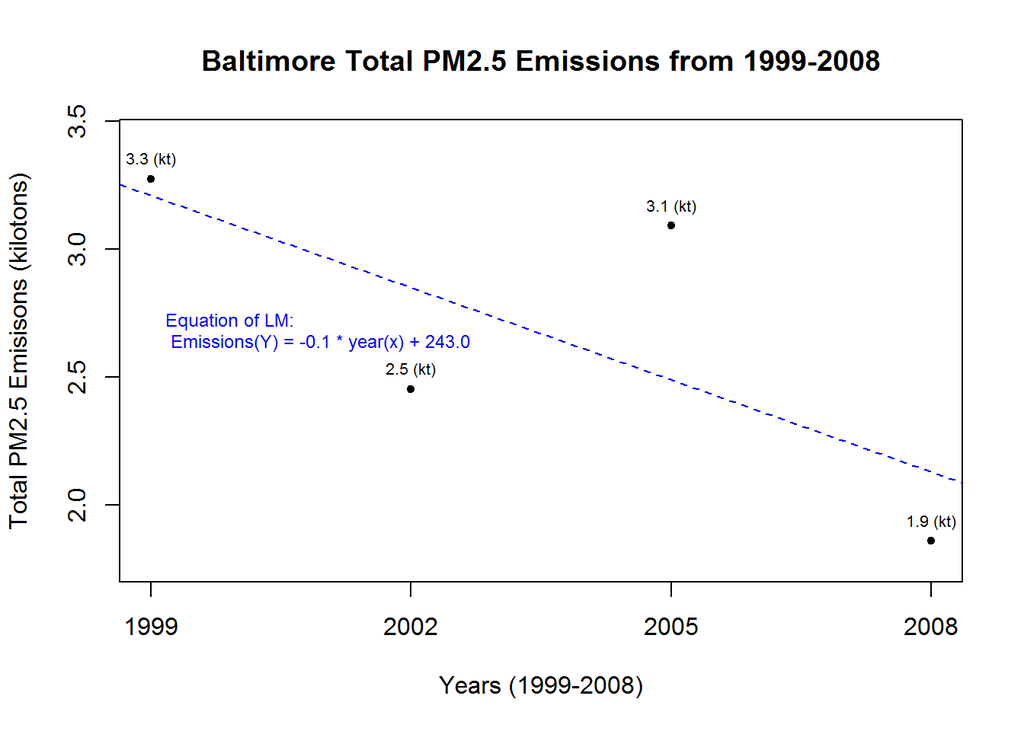

```r
EmissionsSummary_Baltimore <- PMData %>%
  filter(fips == "24510") %>%
  group_by(year) %>%
  summarise(TotalEmissions = sum(Emissions)/1000,
            AvgEmissions = mean(Emissions))

modelBal <- lm(TotalEmissions ~ year,EmissionsSummary_Baltimore)
modelBalEquation <- paste('Equation of LM:\n Emissions(Y) =', format(coef(modelBal)[[2]],nsmall =1, digits = 1,big.mark = ","), '* year(x)', '+', format(coef(modelBal)[[1]],nsmall =1, digits = 2, big.mark = ","))

par(mar=c(5,4,4,2)+0.1)
with(EmissionsSummary_Baltimore,
     plot(year,TotalEmissions,
          ylim = c(min(TotalEmissions)*0.95,max(TotalEmissions)*1.05),
          xaxt = "n",
          main = "Baltimore Total PM2.5 Emissions from 1999-2008",
          xlab = "Years (1999-2008)",
          ylab= "Total PM2.5 Emisisons (kilotons)",
          pch = 20
     )
)
axis(1, at = EmissionsSummary_Total$year)
text(EmissionsSummary_Baltimore$year,EmissionsSummary_Baltimore$TotalEmissions,
     labels= paste(format(EmissionsSummary_Baltimore$TotalEmissions,nsmall =1, digits = 1,big.mark = ","),"(kt)"),
     cex = .65,
     pos = 3
)
abline(modelBal, lwd = 1, lty = "dashed", col = "blue")
text(min(EmissionsSummary_Baltimore$year),mean(EmissionsSummary_Baltimore$TotalEmissions),
     labels = modelBalEquation,
     cex = .75,
     pos = 4,
     col = "blue"
)
```

## Question 3

Of the four types of sources indicated by the **type** (point, nonpoint, onroad, nonroad) variable, which of these four sources have seen decreases in emissions from 1999-2008 for **Baltimore City**? Which have seen increases in emissions from 1999-2008? Use the **ggplot2** plotting system to make a plot answer this question.

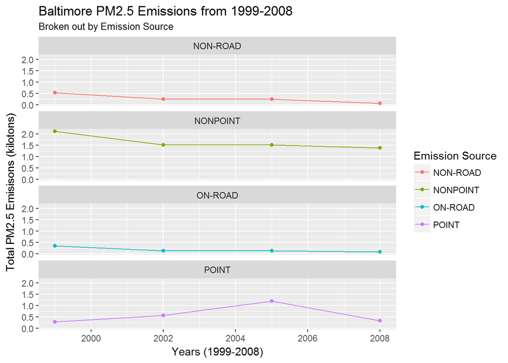

```r
EmissionsSummary_Baltimore_Type <- PMData %>%
  filter(fips == "24510") %>%
  group_by(year, type) %>%
  summarise(TotalEmissions = sum(Emissions)/1000,
            AvgEmissions = mean(Emissions))

ggplot(EmissionsSummary_Baltimore_Type, aes(year,TotalEmissions,col=type)) +
  geom_point() +
  geom_line() +
  facet_wrap(~type,nrow=4) +
  labs(title = "Baltimore PM2.5 Emissions from 1999-2008",
       subtitle = "Broken out by Emission Source",
       x = "Years (1999-2008)",
       y = "Total PM2.5 Emisisons (kilotons)",
       color = "Emission Source"
  )
```

## Question 4

Across the United States, how have emissions from coal combustion-related sources changed from 1999-2008?

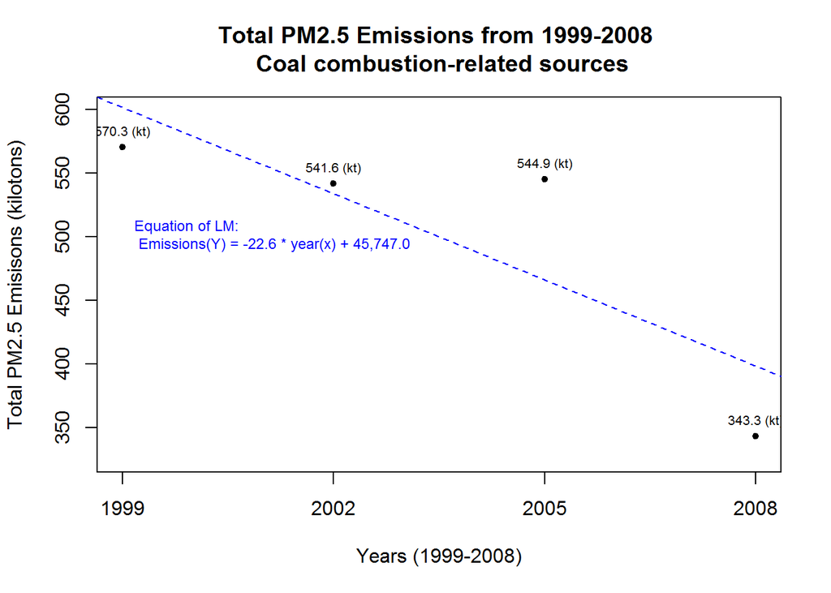

```r
EmissionsSummary_Coal <- PMData %>%
  filter(grepl("Coal",SCC.Level.Three) == TRUE) %>%
  group_by(year) %>%
  summarise(TotalEmissions = sum(Emissions)/1000,
            AvgEmissions = mean(Emissions))

modelCoal <- lm(TotalEmissions ~ year,EmissionsSummary_Coal)
modelCoalEquation <- paste('Equation of LM:\n Emissions(Y) =', format(coef(modelCoal)[[2]],nsmall =1, digits = 1,big.mark = ","), '* year(x)', '+', format(coef(modelCoal)[[1]],nsmall =1, digits = 2, big.mark = ","))

par(mar=c(5,4,4,2)+0.1)
with(EmissionsSummary_Coal,
     plot(year,TotalEmissions,
          ylim = c(min(TotalEmissions)*0.95,max(TotalEmissions)*1.05),
          xaxt = "n",
          main = "Total PM2.5 Emissions from 1999-2008 \n Coal combustion-related sources",
          xlab = "Years (1999-2008)",
          ylab= "Total PM2.5 Emisisons (kilotons)",
          pch = 20
     )
)
axis(1, at = EmissionsSummary_Coal$year)
text(EmissionsSummary_Coal$year,EmissionsSummary_Coal$TotalEmissions,
     labels= paste(format(EmissionsSummary_Coal$TotalEmissions,nsmall =1, digits = 1,big.mark = ","),"(kt)"),
     cex = .65,
     pos = 3
)
abline(modelCoal, lwd = 1, lty = "dashed", col = "blue")
text(min(EmissionsSummary_Coal$year),mean(EmissionsSummary_Coal$TotalEmissions),
     labels = modelCoalEquation,
     cex = .75,
     pos = 4,
     col = "blue"
)
```

## Question 5

How have emissions from motor vehicle sources changed from 1999-2008 in **Baltimore City**?

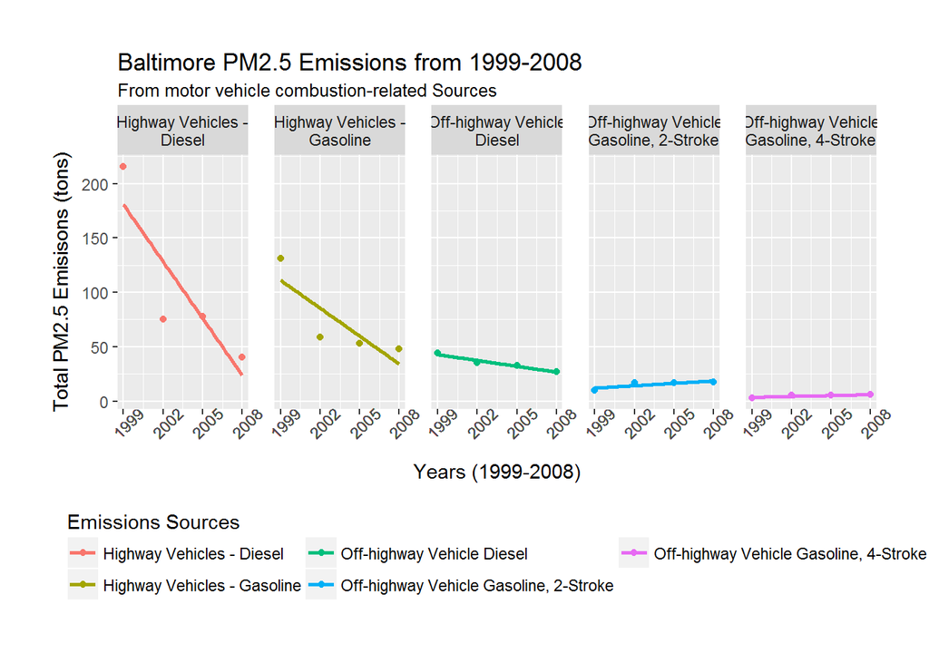

```r
EmissionsSummary_MotorSources_Bal <- PMData %>%
  filter((grepl("Vehicle",SCC.Level.Two) == TRUE),fips == "24510") %>%
  group_by(year, SCC.Level.Two) %>%
  summarise(TotalEmissions = sum(Emissions),
            AvgEmissions = mean(Emissions)) %>%
  rename(Emission_Sources = SCC.Level.Two)

ggplot(EmissionsSummary_MotorSources_Bal, aes(year,TotalEmissions, col = Emission_Sources)) +
  geom_point() +
  facet_wrap(~Emission_Sources,ncol=5,labeller = label_wrap_gen()) +
  scale_x_continuous(breaks = EmissionsSummary_MotorSources_Bal$year) +
  geom_smooth(method= 'lm', se = FALSE) +
  labs(title = "Baltimore PM2.5 Emissions from 1999-2008",
       subtitle = "From motor vehicle combustion-related Sources",
       x = "Years (1999-2008)",
       y = "Total PM2.5 Emisisons (tons)"
  ) +
  theme(legend.position = "bottom",
        axis.text.x = element_text(angle=45),
        panel.spacing = unit(1, "lines"),
        plot.margin = unit(c(1,1,1,1),"cm")
        ) +
  guides(col=guide_legend(title="Emissions Sources",title.position = "top",nrow=2))
```

## Question 6

Compare emissions from motor vehicle sources in **Baltimore City** with emissions from motor vehicle sources in **Los Angeles County**, California (fips == “06037”). Which city has seen greater changes over time in motor vehicle emissions?

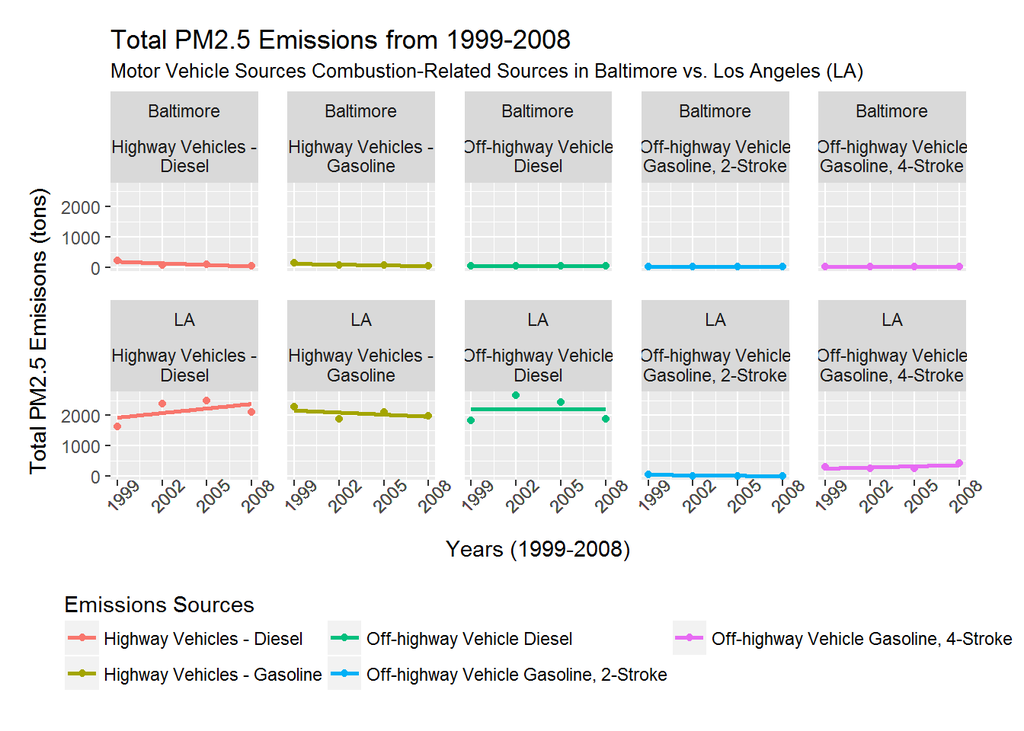

```r
EmissionsSummary_MotorSources_Bal_LA <- PMData %>%
  filter((grepl("Vehicle",SCC.Level.Two) == TRUE),fips %in% c("24510","06037")) %>%
  group_by(year,city, SCC.Level.Two) %>%
  rename(Emission_Sources = SCC.Level.Two) %>%
  summarise(TotalEmissions = sum(Emissions),
            AvgEmissions = mean(Emissions))

ggplot(EmissionsSummary_MotorSources_Bal_LA, aes(year,TotalEmissions, col = Emission_Sources)) +
  geom_point() +
  facet_wrap(city~Emission_Sources,ncol=5, nrow = 2,labeller = label_wrap_gen()) +
  geom_smooth(method= 'lm', se = FALSE) +
  scale_x_continuous(breaks = EmissionsSummary_MotorSources_Bal$year) +
  labs(title = "Total PM2.5 Emissions from 1999-2008",
       subtitle = "Motor Vehicle Sources Combustion-Related Sources in Baltimore vs. Los Angeles (LA)",
       x = "Years (1999-2008)",
       y = "Total PM2.5 Emisisons (tons)",
       fill = "Motor Vehicle Source"
  ) +
  theme(legend.position = "bottom",
        axis.text.x = element_text(angle=45),
        panel.spacing = unit(1, "lines"),
        plot.margin = unit(c(0.5,1,0.5,0.5),"cm")
  ) +
  guides(col=guide_legend(title="Emissions Sources",title.position = "top",nrow=2))
```